# Inferencia

### Construyendo distribuciones conjuntas

En el cuadernillo anterior presentamos la definición de incertidumbre condicional:

$$P(A|B)=\frac{P(A,B)}{P(B)},$$

en donde la marginal $P(B)=\sum_{a}P(A,B)$ puede calcularse a partir de la misma función conjunta $P(A,B)$. En otras palabras, si conocemos la conjunta conocemos las marginales y podemos calcular cualquier condicional.

En aquellos ejemplos partimos de distribuciones conjuntas previamente especificadas y "extrajimos" marginales y condicionales. En la práctica, sin embargo, no siempre resulta práctico intentar especificar *directamente* la distribución conjunta, aunque necesitamos dicha distribución para entender la relación entre las variables involucradas. Por ejemplo, si está en nuestro interés estudiar la relación entre *conducir un automóvil después de una fiesta* y *tener un accidente*, variables con los niveles:

$$A=\begin{cases} A=0: \textrm{no tener accidente}\\ A=1: \textrm{tener accidente}\\ \end{cases}$$$$B=\begin{cases} B=1: \textrm{manejar sin haber consumido alcohol}\\ B=2: \textrm{manejar con el máximo de alcohol permitido}\\ B=3: \textrm{manejar con más del máximo de alcohol permitido}\\ \end{cases}$$

sabemos que la conjunta estará definida en las siguientes dimensiones:

| P(A,B) | A=0 | A=1 |
| --- | --- | --- |
| **B=1** | ? | ? |
| **B=2** | ? | ? |
| **B=3** | ? | ? |

Asignar probabilidades a cada una de estas seis entradas, sin embargo, puede resultar difícil y poco intuitivo pues tendríamos que responder preguntas del estilo: *¿qué porcentaje de la población maneja sin alcohol **y** tiene una accidente?*, o *¿qué proporción de conductores manejan con el máximo de alcohol permitido **y** no tienen un accidente?*, etcétera.

Desde luego podríamos diseñar un estudio enfocado a medir dichas proporciones directamente, pero también es posible utilizar otras piezas de información (que tal vez ya estén disponibles) para "construirla". Por ejemplo, **1.** podríamos consultar a los *valet parking* en las zonas de bares: como devuelven los coches y ven a los conductores, seguramente tienen una idea clara de la incertidumbre marginal $P(B)$, aunque no tengan información sobre la suerte de los conductores una vez que salen del estacionamiento. Por otra parte, **2.** quizá alguna dependencia del gobierno o algún equipo de investigación ha estudiado la incidencia de accidentes en cada tipo de conductor, digamos tomando a 100 conductores sobrios, 100 con el máximo de alcohol permitido, y 100 con más del máximo, y registrando cuántos en cada grupo tienen un accidente la noche de la medición. Esta información permitiría aproximar la distribución condicional $P(A|B)$, aunque no diría nada sobre ninguna marginal.

Ambas distribuciones permiten calcular la conjunta $P(A,B)$ aprovechando que en la identidad

$$P(A|B)=\frac{P(A,B)}{P(B)},$$

podemos despejar $P(A,B)$ multiplicando ambos lados de la ecuación por $P(B)$:

$$P(A|B)P(B)=P(A,B)$$

Por ejemplo, suponiendo que los valet parking nos revelan que

$$P(B)=\begin{cases} P(B=1)=0.2\\ P(B=2)=0.5\\ P(B=3)=0.3,\\ \end{cases}$$

y que el equipo de investigación tiene datos que sugieren

$$P(A|B)=\begin{cases} P(A|B=1)=\begin{cases} P(A=0|B=1)=0.9\\ P(A=1|B=1)=0.1\\ \end{cases}\\\\ P(A|B=2)=\begin{cases} P(A=0|B=2)=0.6\\ P(A=1|B=2)=0.4\\ \end{cases}\\\\ P(A|B=3)=\begin{cases} P(A=0|B=3)=0.2\\ P(A=1|B=3)=0.8,\\ \end{cases} \end{cases}$$

algunas entradas de la conjunta son

$$P(A,B)=\begin{cases} P(A=0,B=1)=P(A=0|B=1)P(B=1)=(0.9)(0.2)=0.18\\ P(A=1,B=1)=P(A=1|B=1)P(B=1)=(0.1)(0.2)=0.02\\ \vdots\\ P(A=1,B=3)=P(A=1|B=3)P(B=3)=(0.8)(0.3)=0.24\\ \end{cases}$$

y la conjunta completa:

| P(B) |  |  | P(A=0\ | B) | P(A=1\ | B) |  |  | P(A,B) | A=0 | A=1 |
| --- | --- | --- | --- | --- | --- | --- | --- | --- | --- | --- | --- |
| **0.2** |  |  | **0.9** | **0.1** |  |  | **B=1** | 0.18 | 0.02 |  |  |
| **0.5** |  |  | **0.6** | **0.4** |  |  | **B=2** | 0.30 | 0.20 |  |  |
| **0.3** |  |  | **0.2** | **0.8** |  |  | **B=3** | 0.06 | 0.24 |  |  |

Pueden comprobar que la función $P(A,B)$ resultante cumple

$$\sum_{a}\sum_{b}P(A,B)=1$$

Nuevamente, una vez que tenemos la conjunta podemos *a.* reproducir la marginal sobre $B$, *b.* calcular la marginal sobre $A$ (desconocida hasta este momento en nuestro estudio), y *c.* calcular cualquier condicional, en cualquier dirección.

La ruta que seguimos para construir la conjunta en el ejemplo anterior no es la única alternativa. También podríamos, por ejemplo, viajar a otra ciudad en donde no existen los *valet*, restricción que nos impide tener acceso a $P(B)$, pero en la que el control de tráfico gubernamental es altamente sofisticado y mediante rastreo satelital permite responder, en cierta noche, *de cada 100 coches circulando, ¿cuántos tienen accidente y cuántos no?* Es decir, en este caso tenemos acceso a $P(A)$, aunque con esta primera medición no sabemos nada sobre el estado de alcohol de los conductores. Aparte, podríamos visitar los centros de detención y los hospitales de la ciudad para registrar el nivel de alcohol en la sangre de aquellos conductores que tuvieron un accidente, aproximando así $P(B|A=1)$ y, aprovechando la información satelital, podríamos visitar a los conductores que llegaron a salvo a su casa y obligarlos a tomar la prueba de alcoholímetro para estimar $P(B|A=0)$.

En otras palabras, en este segundo ejemplo, a diferencia del anterior, calcularemos la conjunta a partir de la marginal sobre $A$, aprovechando que en la definición

$$P(B|A)=\frac{P(A,B)}{P(A)}$$

nuevamente podemos despejar $P(A,B)$, esta vez multiplicando ambos lados por $P(A)$:

$$P(B|A)P(A)=P(A,B),$$

identidad conocida como **regla del producto**.

Suponiendo que en aquella ciudad los satélites registran:

$$P(A)=\begin{cases} P(A=0)=\frac{54}{100}\\\\ P(A=1)=\frac{46}{100} \end{cases}$$

y que al visitar a los 9 conductores que llegaron a sus casas sin accidentes, y al visitar a los 23 accidentados en hospitales, descubrimos, respectivamente:

$$P(B|A)=\begin{cases} P(B|A=0)=\begin{cases} P(B=1|A=0)=\frac{3}{9}\\\\ P(B=2|A=0)=\frac{5}{9}\\\\ P(B=3|A=0)=\frac{1}{9} \end{cases}\\\\ P(B|A=1)=\begin{cases} P(B=1|A=1)=\frac{1}{23}\\\\ P(B=2|A=1)=\frac{10}{23}\\\\ P(B=3|A=1)=\frac{12}{23} \end{cases} \end{cases}$$

Podemos calcular las primeras entradas de la conjunta como:

$$P(A,B)=\begin{cases} P(A=0,B=1)=P(B=1|A=0)P(A=0)=\left(\frac{3}{9}\right)\left(\frac{54}{100}\right)=\frac{162}{900}=0.18\\\\ P(A=1,B=1)=P(B=1|A=1)P(A=1)=\left(\frac{1}{23}\right)\left(\frac{46}{100}\right)=\frac{46}{2300}=0.02\\ \vdots\\ P(A=1,B=3)=P(B=3|A=1)P(A=1)=\left(\frac{12}{23}\right)\left(\frac{46}{100}\right)=\frac{552}{2300}=0.24 \end{cases}$$

Y la conjunta completa:

|  | A=0 | A=1 |
| --- | --- | --- |
| **P(A)** | **54/100** | **46/100** |
| **P(B=1\|A)** | **3/9** | **1/23** |
| **P(B=2\|A)** | **5/9** | **10/23** |
| **P(B=3\|A)** | **1/9** | **12/23** |
| **P(A,B)** | **A=0** | **A=1** |
| **B=1** | 0.18 | 0.02 |
| **B=2** | 0.30 | 0.20 |
| **B=3** | 0.06 | 0.24 |

Resultado que reproduce la conjunta de la primera ciudad. Desde luego, no hay razones para que dicha distribución sea igual en dos ciudades reales, pero hemos elegido estos ejemplos para enfatizar que una sola incertidumbre conjunta puede construirse de dos maneras diferentes:

$$P(A|B)P(B)=P(A,B)$$

y

$$P(B|A)P(A)=P(A,B)$$

### Regla de Bayes

En los dos ejemplos anteriores estudiamos los dos caminos posibles para construir una conjunta de dos dimensiones. Ambas rutas expresan la distribución conjunta $P(A,B)$ como el producto de **una marginal** por la **condicional sobre la otra variable**:

$$P(B|A)P(A)=P(A,B)=P(A|B)P(B),$$

lo cual sugiere que existe cierta relación **específica** entre las condicionales de cada variable, **idea** conocida como **Regla de Bayes**. En concreto, dividiendo ambos lados de la ecuación entre $P(A)$:

$$P(B|A)=\frac{P(A|B)P(B)}{P(A)}$$

y recordando que la marginal $P(A)$ puede calcularse a partir de la conjunta como

$$P(A)=\sum_{b}P(A,B),$$

en donde nuevamente la conjunta puede expresarse como $P(A,B)=P(A|B)P(B)$, lo cual resulta en la expresión para la marginal:

$$P(A)=\sum_{b}P(A|B)P(B)$$

Sustituyendo en la Regla de Bayes:

$$P(B|A)=\frac{P(A|B)P(B)}{\sum_{b}P(A|B)P(B)}$$

Esta expresión permite apreciar la idea completa de la Regla: la incertidumbre actualizada (o *posterior*) sobre alguna de las variables $P(B|A)$, resultado de observar la otra, puede calcularse a partir de **a.** la incertidumbre inicial (o marginal, o *a priori*) sobre dicha variable $P(B)$ y de **b.** la incertidumbre condicional sobre la otra variable dada la variable de interés $P(A|B)$.

#### Ejemplo: Prueba de COVID

En un escenario **ficticio**, imaginen una prueba diseñada para detectar la presencia o ausencia del virus. Esta prueba tiene una tasa de "**positivos correctos**" de **80%**, lo cual quiere decir que de cada 100 personas *que realmente* tienen el virus la prueba responde "positivo" en 80 de ellas. Además, también tiene una tasa de "**falsos positivos**" de **10%**, lo cual indica que de cada 100 personas que *no tienen* el virus el test responde "positivo" para 10 de ellas. Finalmente, aparte de la información sobre el desempeño de la prueba, sabemos que la incidencia del virus es relativamente baja en la población, en tanto que aproximadamente **1 de cada 100** personas tienen el virus.

Imaginen que se aplican la prueba y ésta dice "**positivo**": ¿qué tan probable es que tengan el virus?

Precisando las variables aleatorias del problema:

$$\textrm{Resultado del test: }T\in\{"+","-"\}$$$$\textrm{Presencia o ausencia del virus: }V\in\{\textrm{"sí"},\textrm{"no"}\}$$

Como hemos observado la variable $T="+"$ el problema de inferencia consiste en especificar la incertidumbre condicional sobre la variable $V$ a partir de dicha observación. Es decir, buscamos calcular $P(V|T="+")$. Utilizando la Regla de Bayes:

$$P(V|T)=\frac{P(T|V)P(V)}{\sum_{v}P(T|V)P(V)}$$

Calculando la probabilidad marginal $P(T="+")$:

$$\begin{align} P(V|T="+")&=\frac{P(T="+"|V)P(V)}{\sum_{v}P(T="+"|V)P(V)}\\\\ &=\frac{P(T="+"|V)P(V)}{P(T="+"|V=\textrm{sí})P(V=\textrm{sí})+P(T="+"|V=\textrm{no})P(V=\textrm{no})}\\\\ &=\frac{P(T="+"|V)P(V)}{(0.80)(0.01)+(0.10)(0.99)}\\\\ &=\frac{P(T="+"|V)P(V)}{(0.008)+(0.099)}\\\\ &=\frac{P(T="+"|V)P(V)}{0.107} \end{align}$$

Y calculando la incertidumbre actualizada sobre $V$:

$$\begin{align} P(V=\textrm{sí}|T="+")&=\frac{P(T="+"|V=\textrm{sí})P(V=\textrm{sí})}{0.107}\\\\ &=\frac{(0.80)(0.01)}{0.107}\\\\ &\approx0.075 \end{align}$$

Es decir, después de observar un resultado positivo de la prueba deberíamos concluir que la probabilidad de tener el virus es aproximadamente **7.5%**. Desde luego el otro escenario posible en $V$ contiene el complemento restante:

$$\begin{align} P(V=\textrm{no}|T="+")&=\frac{P(T="+"|V=\textrm{no})P(V=\textrm{no})}{0.107}\\\\ &=\frac{(0.10)(0.99)}{0.107}\\\\ &\approx0.925, \end{align}$$

o bien, después de un resultado positivo tenemos **92.5%** de probabilidad de **no** tener el virus.

Este resultado contraintuitivo resalta la importancia de trabajar con herramientas que permitan traducir y manipular la incertidumbre con reglas estrictas y precisas, en tanto que muchas veces nuestra "intuición probabilística" puede apuntar hacia conclusiones incorrectas. La explicación intuitiva de la probabilidad posterior tan baja para virus es que, como el virus es "raro", o bien es poco probable estar infectado desde antes de tomar la prueba, incluso aunque tengamos evidencia "fuerte" en favor del virus la conclusión actualizada sobre virus debe tomar en cuenta la baja probabilidad inicial. Sin embargo, esto no quiere decir que la prueba sea completamente inútil: noten que después de tener un resultado positivo la probabilidad de tener el virus cambia de $0.01$ a $0.07$, ¡un incremento sustancial! La Regla de Bayes, o bien Teoría de Probabilidad, especifican *exactamente* cómo mezclar ambas piezas de conocimiento (virus raro y prueba eficiente) para construir una conclusión "racional".

Resumiendo, la Regla de Bayes permite calcular la distribución $P(V|T)$ a partir de la (única) región de la conjunta necesaria para hacerlo. En el ejemplo del resultado positivo:

|  | P(V) |  | P(T=+\ | V) | P(T=-\ | V) | P(V,T) | T=+ | T=- |  | P(V\ | T=+) | P(V\ | T=-) |
| --- | --- | --- | --- | --- | --- | --- | --- | --- | --- | --- | --- | --- | --- | --- |
| **V=sí** | 0.01 |  | 0.80 | ? | **V=sí** | 0.008 | ? |  | 0.075 | ? |  |  |  |  |
| **V=no** | 0.99 |  | 0.10 | ? | **V=no** | 0.099 | ? |  | 0.925 | ? |  |  |  |  |
|  |  |  |  |  |  | **0.107** |  |  |  |  |  |  |  |  |

(Aunque, como estudiaremos a lo largo del curso, siempre es recomendable examinar toda la conjunta en la medida de lo posible, porque representa la relación fundamental entre las variables de interés en cualquier modelo.)

#### Ejemplo: Moneda Justa y Tramposa

Consideren dos monedas, una normal y otra que tiene dos águilas. Las ponemos en una bolsa oscura, revolvemos, y tomamos una al azar y, sin examinar sus dos caras, echamos un volado con ella. Observamos "águila". ¿Qué moneda sacamos de la bolsa? O más preciso, *¿qué tan probable es haber sacado cada moneda?*

Variables aleatorias:

$$\mathrm{Moneda\ (\textbf{no observable}):\ }M\in\{\mathrm{justa},\mathrm{tramposa}\}$$$$\mathrm{Volado\ (\textbf{observable}):\ }V\in\{\mathrm{sol},\mathrm{águila}\}$$

Después de observar $V=\mathrm{águila}$ el problema de inferencia consiste en especificar la incertidumbre actualizada sobre $M$, la variable no observable:

$$P(M|V)=\frac{P(V|M)P(M)}{\sum_{m}P(V|M)P(M)}$$

Calculando la probabilidad marginal $P(V=\mathrm{águila})$:

$$\begin{align} P(M|V)&=\frac{P(V|M)P(M)}{\sum_{m}P(V=\mathrm{águila}|M)P(M)}\\\\ &=\frac{P(V|M)P(M)}{P(V=\mathrm{águila}|M=\mathrm{justa})P(M=\mathrm{justa})+P(V=\mathrm{águila}|M=\mathrm{tramposa})P(M=\mathrm{tramposa})}\\\\ &=\frac{P(V|M)P(M)}{\frac{1}{2}\frac{1}{2}+\frac{1}{1}\frac{1}{2}}\\\\ &=\frac{P(V|M)P(M)}{\frac{1}{4}+\frac{1}{2}}\\\\ &=\frac{P(V|M)P(M)}{\frac{3}{4}} \end{align}$$

Es decir, en este experimento la probabilidad de observar $\mathrm{águila}$ antes de sacar la moneda y echarla al aire es igual a $0.75$. Calculando la incertidumbre posterior sobre $M$:

$$\begin{align} P(M=\mathrm{justa}|V=\mathrm{águila})&=\frac{P(V=\mathrm{águila}|M=\mathrm{justa})P(M=\mathrm{justa})}{\frac{3}{4}}\\ &=\frac{\frac{1}{4}}{\frac{3}{4}}\\\\ &=\frac{1}{3}\\\\ P(M=\mathrm{tramposa}|V=\mathrm{águila})&=\frac{P(V=\mathrm{águila}|M=\mathrm{tramposa})P(M=\mathrm{tramposa})}{\frac{3}{4}}\\ &=\frac{\frac{1}{2}}{\frac{3}{4}}\\\\ &=\frac{2}{3} \end{align}$$

#### Ejemplo: Ladrón y ADN

Imaginen que un ladrón roba una joyería a mitad de la noche. La policía detiene a tres sospechosos, pero sabe que sólo uno es responsable porque las cámaras de vigilancia graban a una persona. Lo sospechosos son:

$$\mathrm{Ladrón:\ } L\in\ \begin{cases} L=1: \textrm{Pablo, que cuenta con antecedentes penales}\\ L=2: \textrm{Pedro, que tiene deudas importantes}\\ L=3: \textrm{Poncho, que está desempleado, y es hermano de Pedro} \end{cases} $$

A falta de mayor evidencia, la incertidumbre inicial de la policía con esta información es:

$$P(L)=\ \begin{cases} P(L=1)=0.70\\ P(L=2)=0.20\\ P(L=3)=0.10\\ \end{cases} $$

Unos días después, sin embargo, el equipo de peritos encuentra un cabello en la escena del crimen y al examinar su ADN los especialistas reportan "evidencia del ADN de Poncho". Este reporte no es definitivo porque las técnicas y equipo del laboratorio no permiten llegar a una conclusión segura, y además es posible explicar la presencia de un cabello de Poncho sin suponerlo en la escena del crimen. Para cuantificar estos escenarios de manera precisa la policía utiliza la siguiente *función de verosimilitud*, como también se le conoce a la condicional $P(\textrm{Evidencia}|\textrm{Hipótesis})$:

$$P(E|L)=\ \begin{cases} P(E|L=1)=0.05\\ P(E|L=2)=0.60\\ P(E|L=3)=0.80\\ \end{cases} $$

Actualizando la incertidumbre sobre $L$:

$$\begin{align} P(L|E)&=\frac{P(E|L)P(L)}{\sum_l P(E|L)P(L)}\\ &=\frac{P(E|L)P(L)}{P(E|L=1)P(L=1)+P(E|L=2)P(L=2)+P(E|L=3)P(L=3)}\\\\ &=\frac{P(E|L)P(L)}{(0.05)(0.70)+(0.60)(0.20)+P(0.80)P(0.10)}\\\\ &=\frac{P(E|L)P(L)}{0.235}\\\\ P(L=1|E)&=\frac{P(E|L=1)P(L=1)}{0.235}\\\\ &=\frac{0.035}{0.235}\\\\ &\approx 0.149\\\\ P(L=2|E)&=\frac{P(E|L=2)P(L=2)}{0.235}\\\\ &=\frac{0.120}{0.235}\\\\ &\approx 0.511\\\\ P(L=3|E)&=\frac{P(E|L=3)P(L=3)}{0.235}\\\\ &=\frac{0.080}{0.235}\\\\ &\approx 0.340 \end{align}$$

Es decir, después de observar la evidencia del cabello el principal sospechoso ahora es $L=2: \textrm{Pedro}$, ¡aunque no era ni el principal sospechoso al inicio, ni el sospechoso bajo el cual la evidencia era más probable!

Noten que la **distribución a priori** $P(L)$, la **distribución posterior** $P(L|E)$, y la **función de verosimilitud** $P(E|L)$ están definidas sobre $L$. La primera representa el conocimiento sobre $L$ *antes* de observar la evidencia $E$; la segunda representa el conocimiento actualizado sobre $L$ *después* de tomar en cuenta la evidencia; y la tercera representa *qué tan plausible es la evidencia* $E$ bajo cada posible escenario en el espacio de hipótesis $L$. Como hemos estudiado en este apunte, la Regla de Bayes, y en general las reglas y definiciones en Teoría de Probabilidad, especifican la relación entre estas funciones. En concreto: la distribución posterior es una "mezcla" entre la incertidumbre a priori y la función de verosimilitud:

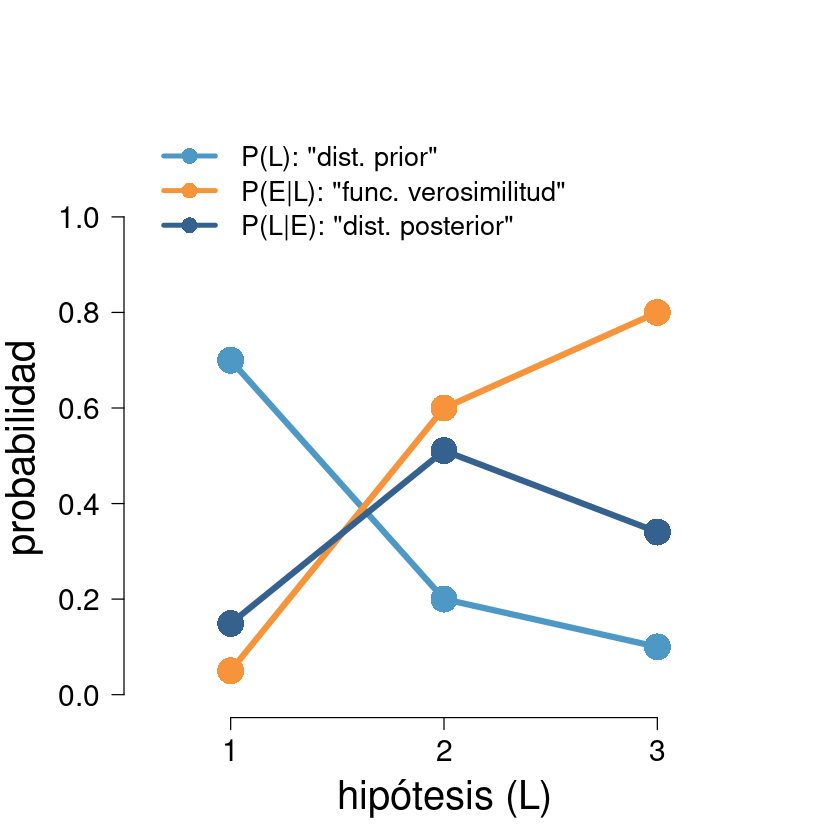

```r
L <- c(1,2,3) # Hypothesis space
P_L <- c(0.70,0.20,0.10) # Prior
P_E_d_L <- c(0.05,0.60,0.80) # Likelihood
P_L_d_E <- P_L*P_E_d_L/sum(P_L*P_E_d_L) # Posterior (by Bayes)
col_prior <- '#4d98c5'
col_post <- '#35618f'
col_like <- '#f5943b'
par(cex.axis=1.5)
plot(NULL,xlim=c(.5,3.5),ylim=c(0,1.2),ann=F,axes=F)
axis(1,at=L);axis(2,at=seq(0,1,.2),pos=0.5,las=1)
mtext('hipótesis (L)',1,line=3,cex=2)
mtext('probabilidad',2,line=2.5,cex=2,adj=.4)
points(L,P_L,type='o',col=col_prior,cex=3,lwd=5,pch=16)
points(L,P_E_d_L,type='o',col=col_like,cex=3,lwd=5,pch=16)
points(L,P_L_d_E,type='o',col=col_post,cex=3,lwd=5,pch=16)
legend(.65,1.2,yjust=1,xjust=0,
      legend=c('P(L): "dist. prior"','P(E|L): "func. verosimilitud"','P(L|E): "dist. posterior"'),
      pch=16,lwd=4,seg.len=2,pt.cex=1.75,cex=1.35,box.lty='blank',
      col=c(col_prior,col_like,col_post))
```

### Ejercicios

1. Partiendo del ejemplo de las monedas justa (águila y sol) y tramposa (dos águilas), ¿qué deberíamos concluir si, después de tomar una moneda al azar y lanzar el volado, en lugar de observar águila observáramos **sol**? Intenta anticipar el resultado intuitivo y después calcula con precisión usando la Regla de Bayes.
2. Cierta comunidad que vive en una península sabe que sus enemigos están planeando conquistarla. Los enemigos disponen de 4 formas de ataque: por barco, por submarino, por aire, o por tierra, y en invasiones en siglos pasados han utilizado barcos el 20%, submarinos el 40%, aviones el 30%, y tanques el 10% de sus ataques. Además, la comunidad sabe que los enemigos se comunican la decisión por radio, con los siguientes códigos: `[raya,punto]=barcos`, `[raya,raya]=submarinos`, `[punto,raya]=aviones`, y `[punto,punto]=tanques`. El día del ataque el analista de la comunidad encargado de espiar las transmisiones enemigas se distrae y sólo alcanza a escuchar la segunda parte de la señal, que es `[____,punto]`. ¿Qué debería de creer la comunidad sobre la vía del ataque enemigo después de observar esta evidencia?

### Soluciones

1. Utilizando la misma incertidumbre inicial sobre las posibles hipótesis (monedas):

$$P(M)=\begin{cases} P(M=\mathrm{justa})=\frac{1}{2}\\ P(M=\mathrm{tramposa})=\frac{1}{2}, \end{cases}$$

y la función de verosimilitud para el resultado $\mathrm{sol}$:

$$P(V=\mathrm{sol}|M)=\begin{cases} P(V=\mathrm{sol}|M=\mathrm{justa})=\frac{1}{2}\\ P(V=\mathrm{sol}|M=\mathrm{tramposa})=0 \end{cases}$$

Es decir, la función de verosimilitud hace explícito que es *imposible* observar la evidencia con la que contamos es bajo ciertas hipótesis. Utilizando la Regla de Bayes para calcular la incertidumbre posterior sobre éstas:

$$\begin{align}P(M|V=\mathrm{sol})&=\frac{P(V=\mathrm{sol}|M)P(M)}{\sum_m P(V=\mathrm{sol}|M)P(M)}\\ &=\frac{P(V=\mathrm{sol}|M)P(M)}{P(V=\mathrm{sol}|M=\mathrm{justa})P(M=\mathrm{justa})+P(V=\mathrm{sol}|M=\mathrm{tramposa})P(M=\mathrm{tramposa})}\\\\ &=\frac{P(V=\mathrm{sol}|M)P(M)}{\frac{1}{2}\frac{1}{2}+0\frac{1}{2}}\\\\ &=\frac{P(V=\mathrm{sol}|M)P(M)}{\frac{1}{4}}\\\\ P(M=\mathrm{justa}|V=\mathrm{sol})&=\frac{P(V=\mathrm{sol}|M=\mathrm{justa})P(M=\mathrm{justa})}{\frac{1}{4}}\\ &=\frac{\frac{1}{2}\frac{1}{2}}{\frac{1}{4}}\\ &=1\\\\ P(M=\mathrm{tramposa}|V=\mathrm{sol})&=\frac{P(V=\mathrm{sol}|M=\mathrm{tramposa})P(M=\mathrm{tramposa})}{\frac{1}{4}}\\ &=\frac{0\frac{1}{2}}{\frac{1}{4}}\\ &=0\\ \end{align}$$

1. Construyendo la incertidumbre inicial sobre las posibles hipótesis (medios de ataque) con base en el comportamiento del enemigo en las invasiones anteriores:

$$P(A)=\begin{cases} P(A=\mathrm{barcos})=0.2\\ P(A=\mathrm{submarinos})=0.4\\ P(A=\mathrm{aviones})=0.3\\ P(A=\mathrm{tanques})=0.1\\ \end{cases}$$

y la función de verosimilitud, que cuantifica la plausibilidad de la evidencia bajo cada hipótesis:

$$P(E|A)=\begin{cases} P(E|A=\mathrm{barcos})=0.5\\ P(E|A=\mathrm{submarinos})=0\\ P(E|A=\mathrm{aviones})=0\\ P(E|A=\mathrm{tanques})=0.5,\\ \end{cases}$$

en donde nuevamente es evidente que la evidencia es imposible bajo ciertas hipótesis. Actualizando la incertidumbre sobre cada hipótesis:

$$\begin{align} P(A|E)&=\frac{P(E|A)P(A)}{\sum_{a}P(E|A)P(A)}\\ &=\frac{P(E|A)P(A)}{P(E|A=\mathrm{barcos})P(A=\mathrm{barcos})+P(E|A=\mathrm{submarinos})P(A=\mathrm{submarinos})+P(E|A=\mathrm{aviones})P(A=\mathrm{aviones})+P(E|A=\mathrm{tanques})P(A=\mathrm{tanques})}\\\\ &=\frac{P(E|A)P(A)}{(0.5)(0.2)+(0)(0.4)+(0)(0.3)+(0.5)(0.1)}\\\\ &=\frac{P(E|A)P(A)}{0.15}\\\\ P(A=\mathrm{barcos}|E)&=\frac{P(E|A=\mathrm{barcos})P(A=\mathrm{barcos})}{0.15}\\ &=\frac{(0.5)(0.2)}{0.15}\\\\ &=\frac{2}{3}\\\\ P(A=\mathrm{submarinos}|E)&=\frac{P(E|A=\mathrm{submarinos})P(A=\mathrm{submarinos})}{0.15}\\ &=\frac{(0)(0.4)}{0.15}\\\\ &=0\\\\ P(A=\mathrm{aviones}|E)&=\frac{P(E|A=\mathrm{aviones})P(A=\mathrm{aviones})}{0.15}\\ &=\frac{(0)(0.3)}{0.15}\\\\ &=0\\\\ P(A=\mathrm{tanques}|E)&=\frac{P(E|A=\mathrm{tanques})P(A=\mathrm{tanques})}{0.15}\\ &=\frac{(0.5)(0.1)}{0.15}\\\\ &=\frac{1}{3}\\ \end{align}$$

Los resultados de ambos ejercicios demuestran que podemos alcanzar conclusiones "drásticas" sobre ciertas hipótesis utilizando el mismo conjunto de herramientas de inferencia: podemos "falsear" o descartar hipótesis si encontramos evidencia que éstas no puedan explicar, y a veces podemos "confirmar" cierto modelo si es el único que puede dar cuenta de la evidencia a la mano.

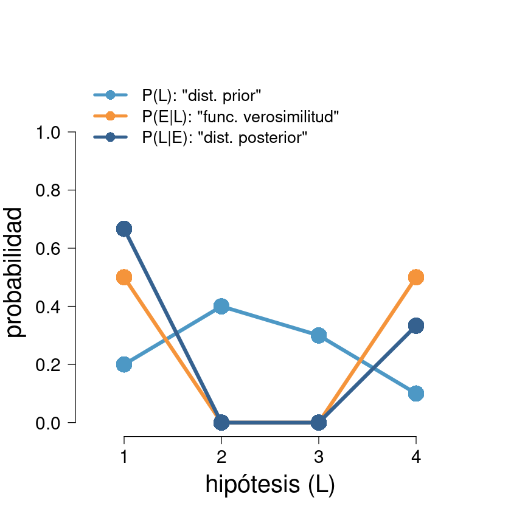

```r
L <- c(1,2,3,4) # Hypothesis space
P_L <- c(0.20,0.40,0.30,0.10) # Prior
P_E_d_L <- c(0.5,0,0,0.5) # Likelihood
P_L_d_E <- P_L*P_E_d_L/sum(P_L*P_E_d_L) # Posterior (by Bayes)
col_prior <- '#4d98c5'
col_post <- '#35618f'
col_like <- '#f5943b'
par(cex.axis=1.5)
plot(NULL,xlim=c(.5,4.5),ylim=c(0,1.2),ann=F,axes=F)
axis(1,at=L);axis(2,at=seq(0,1,.2),pos=0.5,las=1)
mtext('hipótesis (L)',1,line=3,cex=2)
mtext('probabilidad',2,line=2.5,cex=2,adj=.4)
points(L,P_L,type='o',col=col_prior,cex=3,lwd=5,pch=16)
points(L,P_E_d_L,type='o',col=col_like,cex=3,lwd=5,pch=16)
points(L,P_L_d_E,type='o',col=col_post,cex=3,lwd=5,pch=16)
legend(.65,1.2,yjust=1,xjust=0,
      legend=c('P(L): "dist. prior"','P(E|L): "func. verosimilitud"','P(L|E): "dist. posterior"'),
      pch=16,lwd=4,seg.len=2,pt.cex=1.75,cex=1.35,box.lty='blank',
      col=c(col_prior,col_like,col_post))
```

1. Otra posible solución del segundo problema consiste en interpretar la primera ($V_1$) y la segunda parte de la señal ($V_2$) como las variables relevantes. Bajo esta interpretación, la distribución sobre los posibles medios de ataque es la distribución conjunta entre $V_1$ y $V_2$:

| P($V_1$,$V_2$) | $V_1$=punto | $V_1$=raya | P($V_2$) |
| --- | --- | --- | --- |
| **$V_2$=punto** | 0.10 | 0.20 | **0.30** |
| **$V_2$=raya** | 0.30 | 0.40 | **0.70** |
| **P($V_1$)** | **0.40** | **0.60** |  |

Observamos $V_2=punto$. Utilizando ese conocimiento podemos actualizar nuestra incertidumbre sobre $V_1$, es decir, calcular qué tan probable es que la primera parte de la señal haya sido punto o raya, cada una de dichas posibilidades asociada a tanques y barcos, respectivamente:

$$\begin{align} P(V_1=punto|V_2=punto)&=\frac{P(V_1=punto,V_2=punto)}{P(V_2=punto)}\\\\ &=\frac{0.10}{0.30}\\\\ &=\frac{1}{3}\\\\ P(V_1=raya|V_2=punto)&=\frac{P(V_1=raya,V_2=punto)}{P(V_2=punto)}\\\\ &=\frac{0.20}{0.30}\\\\ &=\frac{2}{3}\\\\ \end{align}$$

Que reproduce la misma conclusión alcanzada por la ruta anterior.

### Referencias recomendadas

- McGrayne, S. B. (2011). *The Theory that Would Not Die: How Bayes' Rule cracked the enigma code, hunted down russian submarines, and emerged triumphant from two centuries of controversy.* Yale University Press.
- *Bayesian Inference is Just Counting*, by Richard McElreath: https://www.youtube.com/watch?v=_NEMHM1wDfI&t=1689s